# Freight Short Call Utilization

Crew Resource Planning

Published

2024-08-28

### Freight Short Call Reserve Utilization

**9.39 %** of Freight Short Call periods utilized between both Captains and First Officers across **671 total** Freight Short Call periods from **2023-11-02** to **2024-08-31**.

#### Percent Utilization of Freight Short Call Reserve Captains and First Officers per Month

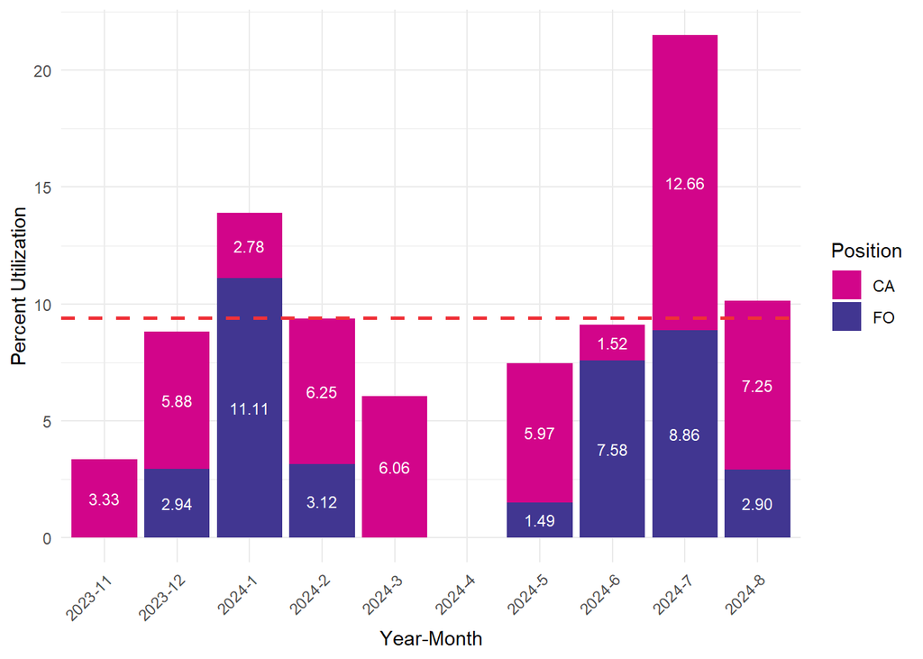

#### Individual Captain and First Officer Utilization

|  | FLIGHT_NO | SEGMENT_POSITION | CREW_ID | FLIGHT_DATE | DEPARTING_CITY | ARRIVAL_CITY | PAIRING_NO | PAIRING_DATE | SCHED_DEPARTURE_DATE | SCHED_DEPARTURE_TIME | SCHED_ARRIVAL_DATE | SCHED_ARRIVAL_TIME |
| --- | --- | --- | --- | --- | --- | --- | --- | --- | --- | --- | --- | --- |
| 1 | 1601 | FO | 24432 | 2024-08-26 | SBD | CVG | C2501F | 2024-08-23 | 2024-08-26 | 11:00:00 | 2024-08-26 | 18:13:00 |
| 2 | 1601 | FO | 24432 | 2024-08-24 | SBD | CVG | C2501E | 2024-08-23 | 2024-08-24 | 11:00:00 | 2024-08-24 | 18:13:00 |
| 3 | 1601 | CA | 15637 | 2024-08-23 | SBD | CVG | C2501I | 2024-08-19 | 2024-08-23 | 11:00:00 | 2024-08-23 | 18:13:00 |
| 4 | 1688 | CA | 15637 | 2024-08-21 | HNL | SBD | C2501I | 2024-08-19 | 2024-08-21 | 22:10:00 | 2024-08-22 | 06:53:00 |
| 5 | 1621 | CA | 15637 | 2024-08-20 | SBD | HNL | C2501I | 2024-08-19 | 2024-08-20 | 15:00:00 | 2024-08-20 | 18:10:00 |
| 6 | 1617 | CA | 14880 | 2024-08-07 | SBD | JFK | C2501L | 2024-08-03 | 2024-08-07 | 14:16:00 | 2024-08-07 | 22:31:00 |
| 7 | 1688 | CA | 9844 | 2024-08-01 | HNL | SBD | C2501F | 2024-07-30 | 2024-08-01 | 22:10:00 | 2024-08-02 | 06:53:00 |
| 8 | 1621 | CA | 9844 | 2024-07-31 | SBD | HNL | C2501F | 2024-07-30 | 2024-07-31 | 15:00:00 | 2024-07-31 | 18:10:00 |
| 9 | 1601 | FO | 22961 | 2024-07-23 | SBD | CVG | C2501K | 2024-07-18 | 2024-07-23 | 11:00:00 | 2024-07-23 | 18:13:00 |
| 10 | 1601 | CA | 9841 | 2024-07-22 | SBD | CVG | C2501L | 2024-07-18 | 2024-07-22 | 11:00:00 | 2024-07-22 | 18:13:00 |

[output cut: 53 more lines]

$~$

$~$

### Data Pipeline

$~$

##### Packages

```r
if (!require(librarian)){
  install.packages("librarian")
  library(librarian)
}

# librarian downloads, if not already downloaded, and reads in needed packages
librarian::shelf(tidyverse, here, janitor, lubridate, stringr, DBI,
                 odbc, DT, rstudioapi, dbplyr, plotly)
```

##### Database Connection

```r
### Connect to `Snowflake` Database
tryCatch({
    db_connection <- DBI::dbConnect(odbc::odbc(),
                             Driver="SnowflakeDSIIDriver",
                             Server="hawaiianair.west-us-2.azure.snowflakecomputing.com",
                             WAREHOUSE="DATA_LAKE_READER",
                             Database="ENTERPRISE",
                             UID= Sys.getenv("UID"),
                             authenticator = "externalbrowser")
    print("Database Connected!")
    },
    error=function(cond) {
            print("Unable to connect to Database.")
})




# Set search_path
dbExecute(db_connection, "USE SCHEMA CREW_ANALYTICS")
```

##### Query `CT_DEADHEAD`, `CT_FLIGHT_LEG`, and `CT_MASTER_PAIRING` Tables

- Filter `PAIRING_DATE` between current date to one year prior
- Filter `CREW_INDICATOR` for `P` and `FLIGHT_NO` for `FSC`

```r
fetch_data <- function(query, var_name) {
  if (!exists(var_name, envir = .GlobalEnv)) {
    assign(var_name, dbGetQuery(db_connection, query), envir = .GlobalEnv)
    message(paste("Data fetched and stored in", var_name))
  } else {
    message(paste(var_name, "already exists. Skipping database query."))
  }
}

# Deadhead Query
q_deadhead <- "SELECT *
               FROM CT_DEADHEAD
               WHERE PAIRING_DATE BETWEEN DATEADD(YEAR, -1, CURRENT_DATE()) AND CURRENT_DATE()
               AND CREW_INDICATOR = 'P'
               AND FLIGHT_NO = 'FSC';"

fetch_data(q_deadhead, "view_deadhead")

# FlightLeg Query
q_flightleg <- "SELECT *
                FROM CT_FLIGHT_LEG
                WHERE PAIRING_DATE BETWEEN DATEADD(YEAR, -1, CURRENT_DATE()) AND CURRENT_DATE()
                AND CREW_INDICATOR = 'P';"

fetch_data(q_flightleg, "view_flightleg")

# MasterPairing Query
q_masterpairing <- "SELECT *
                    FROM CT_MASTER_PAIRING
                    WHERE PAIRING_DATE BETWEEN DATEADD(YEAR, -1, CURRENT_DATE()) AND CURRENT_DATE()
                    AND CREW_INDICATOR = 'P';"

fetch_data(q_masterpairing, "view_masterpairing")
```

#### Necessary Data Cleaning Steps

$~$

##### CT_DEADHEAD

- Filter `PAIRING_NO` for partial match of `C250` to get all FSC flights
- Concatenate `UPDATE_DATE` and `UPDATE_TIME` to `updated_dt`
- Group by `SCHED_DEPARTURE_DATE`, `PAIRING_POSITION`
- Filter for most recent `updated_dt` version

```r
clean_deadhead <- view_deadhead %>%
  filter(str_detect(PAIRING_NO, "C250")) %>% # FSC Days
  mutate(updated_dt = paste(UPDATE_DATE, UPDATE_TIME, sep = " ")) %>%
  relocate(updated_dt, .after=PAIRING_NO) %>%
  group_by(SCHED_DEPARTURE_DATE, PAIRING_POSITION) %>%
  filter(updated_dt == max(updated_dt)) %>%
  mutate(temp_id = cur_group_id()) %>%
  filter(!duplicated(temp_id))
```

##### CT_FLIGHT_LEG

- Filter `PAIRING_NO` for partial match of `C250` to get all FSC flights
- Concatenate `UPDATE_DATE` and `UPDATE_TIME` to `updated_dt`
- Group by `DEPARTING_CITY`, `ARRIVAL_CITY`, `SEGMENT_POSITION`, `SCHED_DEPARTURE_DATE`, `SCHED_DEPARTURE_TIME`
- Filter for most recent `updated_dt` version
- Remove any `D` observations in `DEADHEAD` column

```r
clean_flightleg <- view_flightleg %>%
  filter(str_detect(PAIRING_NO, "C250")) %>% # FSC Days
  mutate(updated_dt = paste0(UPDATE_DATE, UPDATE_TIME)) %>%
  relocate(updated_dt, .after=PAIRING_NO) %>%
  group_by(DEPARTING_CITY, ARRIVAL_CITY, SEGMENT_POSITION, SCHED_DEPARTURE_DATE, SCHED_DEPARTURE_TIME) %>%
  filter(updated_dt == max(updated_dt)) %>%
  filter(is.na(DEADHEAD))
```

##### CT_MASTER_PAIRING

- Filter `PAIRING_NO` for partial match of `C250` to get all FSC flights
- Concatenate `UPDATE_DATE` and `UPDATE_TIME` to `updated_dt`
- Group by `CREW_ID` and `PAIRING_DATE`
- Filter for most recent `updated_dt` version

```r
clean_masterpairing <- view_masterpairing %>%
  filter(str_detect(PAIRING_NO, "C250")) %>% # FSC Days
  mutate(updated_dt = paste0(UPDATE_DATE, UPDATE_TIME)) %>%
  relocate(updated_dt, .after=PAIRING_NO) %>%
  group_by(PAIRING_DATE, CREW_ID) %>% # Some updated times occurred at the same time
  filter(updated_dt == max(updated_dt)) %>%
  mutate(temp_id = cur_group_id())
```

##### Freight Short Call Reserve Pilots Called Up

- Join `clean_flightleg` onto `clean_masterpairing` by `PAIRING_DATE` and `PAIRING_NO`

```r
fl_mp <- clean_flightleg %>%
  left_join(clean_masterpairing, by = c("PAIRING_DATE", "PAIRING_NO")) %>%
  relocate(SEGMENT_POSITION, .after = FLIGHT_NO) %>%
  relocate(CREW_ID, .after = SEGMENT_POSITION) %>%
  relocate(PAIRING_STATUS, .after = SCHED_DEPARTURE_DATE) %>%
  drop_na(CREW_ID) %>%
  select(c(FLIGHT_NO:PAIRING_NO), PAIRING_DATE, SCHED_DEPARTURE_DATE,
         SCHED_DEPARTURE_TIME,  SCHED_ARRIVAL_DATE, SCHED_ARRIVAL_TIME) %>%
  arrange(desc(SCHED_DEPARTURE_DATE)) %>%
  group_by(CREW_ID, SCHED_DEPARTURE_DATE) %>%
  filter(!duplicated(CREW_ID))
```

##### Percent Utilization of Freight Short Call Reserve Captains or First Officers per Month

- Sum year-monthly flight periods
- Sum CA and FO utilization per year-month
- Calculate percent CA and FO utilized per year-month
- Visualize

```r
# all FSC periods in which a pilot was called up
m_m_tot_fl_mp <- fl_mp %>%
  ungroup() %>%
  select(FLIGHT_DATE, DEPARTING_CITY, ARRIVAL_CITY)

# all possible FSC periods and periods in which a pilot was called up
m_m_tot <- clean_deadhead %>%
  ungroup() %>%
  select(FLIGHT_DATE, DEPARTING_CITY, ARRIVAL_CITY) %>%
  rbind(m_m_tot_fl_mp) %>%
  mutate(flight_month = month(FLIGHT_DATE),
         flight_year = year(FLIGHT_DATE),
         flight_ym = paste(flight_year, flight_month, sep="-")) %>%
  group_by(flight_ym) %>%
  summarise(sum_month = sum(n()))


# FSC periods in which a pilot was called uo
m_m_ut <- fl_mp %>%
  mutate(flight_month = month(FLIGHT_DATE),
         flight_year = year(FLIGHT_DATE),
         flight_ym = paste(flight_year, flight_month, sep="-")) %>%
  group_by(flight_ym, SEGMENT_POSITION) %>%
  reframe(sum_ut = sum(n())) %>%
  ungroup() %>%
  complete(flight_ym, SEGMENT_POSITION) %>%
  inner_join(m_m_tot, by = c("flight_ym")) %>%
  mutate(sum_ut = if_else(is.na(sum_ut), 0, sum_ut)) %>%
  mutate(perc_ut = (sum_ut/(sum_month)*100))



# list of all year-month combos
min_month_year <- min(m_m_ut$flight_ym)
start_date <- ymd(paste0(min_month_year, "1"))
end_date <- ceiling_date(Sys.Date(), "month") - months(1)
all_dates <- seq(start_date, end_date, by = "month")

# Create a dataframe with all month-year combinations
complete_combinations <- data.frame(
  flight_ym = format(all_dates, "%Y-%m"),
  SEGMENT_POSITION = rep(c("CA", "FO"), each = length(all_dates))
)

# Remove trailing zeroes after the dash
complete_combinations$flight_ym <- gsub("-0([1-9])", "-\\1", complete_combinations$flight_ym)

# year-month combos with no data
missing_dates <- anti_join(complete_combinations, m_m_ut)

# complete data frame with zero year-months
complete_data <- m_m_ut %>%
  full_join(missing_dates)

# Make ggplot
ggplot(complete_data, aes(x = factor(flight_ym), y = perc_ut, fill = SEGMENT_POSITION)) +
  geom_bar(stat = "identity") +
  geom_text(aes(label = ifelse(perc_ut == 0, NA, sprintf("%.2f", perc_ut))),
            position = position_stack(vjust = 0.5),
            color = "white", size = 3) +
  geom_hline(yintercept = ans, color = "#EF3138", linetype = "dashed", size = 1) +
  labs(x = "Year-Month", y = "Percent Utilization", fill = "Position") +
  theme_minimal() +
  scale_fill_manual(values = c("FO" = "#413691", "CA" = "#D2058A")) +
  theme(axis.text.x = element_text(angle = 45, hjust = 1))
```